# Project3: Build a Traffic Sign Recognition Classifier

## Step 0: Load The Data

```python
from __future__ import absolute_import
from __future__ import division
from __future__ import print_function

import matplotlib.pyplot as plt
import tensorflow as tf
from tensorflow.contrib.layers import flatten
from tensorflow.examples.tutorials.mnist import input_data
from sklearn.utils import shuffle
import cv2
%matplotlib inline

tf.logging.set_verbosity(tf.logging.INFO)
```

```python
## Step 0: Load The Data

# Load pickled data
import pickle
import numpy as np
# TODO: Fill this in based on where you saved the training and testing data

training_file = '../data/train.p'
validation_file= '../data/valid.p'
testing_file = '../data/test.p'

with open(training_file, mode='rb') as f:
    train = pickle.load(f)
with open(validation_file, mode='rb') as f:
    valid = pickle.load(f)
with open(testing_file, mode='rb') as f:
    test = pickle.load(f)

X_train, y_train = train['features'], train['labels'].astype(np.int32)
X_valid, y_valid = valid['features'], valid['labels'].astype(np.int32)
X_test, y_test = test['features'], test['labels'].astype(np.int32)
```

## Step 1: Dataset Summary & Exploration

The pickled data is a dictionary with 4 key/value pairs:

- `'features'` is a 4D array containing raw pixel data of the traffic sign images, (num examples, width, height, channels).
- `'labels'` is a 1D array containing the label/class id of the traffic sign. The file `signnames.csv` contains id -> name mappings for each id.
- `'sizes'` is a list containing tuples, (width, height) representing the original width and height the image.
- `'coords'` is a list containing tuples, (x1, y1, x2, y2) representing coordinates of a bounding box around the sign in the image. **THESE COORDINATES ASSUME THE ORIGINAL IMAGE. THE PICKLED DATA CONTAINS RESIZED VERSIONS (32 by 32) OF THESE IMAGES**

Complete the basic data summary below. Use python, numpy and/or pandas methods to calculate the data summary rather than hard coding the results. For example, the [pandas shape method](http://pandas.pydata.org/pandas-docs/stable/generated/pandas.DataFrame.shape.html) might be useful for calculating some of the summary results.

### Provide a Basic Summary of the Data Set Using Python, Numpy and/or Pandas

```python
### Replace each question mark with the appropriate value.
### Use python, pandas or numpy methods rather than hard coding the results

# TODO: Number of training examples
n_train = X_train.shape[0]

# TODO: Number of validation examples
n_validation = X_valid.shape[0]

# TODO: Number of testing examples.
n_test = X_test.shape[0]

# TODO: What's the shape of an traffic sign image?
image_shape = X_train[0].shape

# TODO: How many unique classes/labels there are in the dataset.
n_classes = len(np.unique(y_train))

print("Number of training examples =", n_train)
print("Number of validation examples =", n_validation)
print("Number of testing examples =", n_test)
print("Image data shape =", image_shape)
print("Number of classes =", n_classes)
```

```
Number of training examples = 34799
Number of validation examples = 4410
Number of testing examples = 12630
Image data shape = (32, 32, 3)
Number of classes = 43
```

### Explore Bad Patterns

Random checked 200 images and found out some patterns of images' crashing. And here are some examples of them.

| Index | Problem |
| --- | --- |
| 6223 | High contrast (bright outside) |
| 29041 | High contrast (bright inside) |
| 19591 | Partly high contrast |
| 28593 | Multiple signs |
| 7657 | Fog (weather) |
| 6302 | Extremely dark |
| 15120 | Dark |

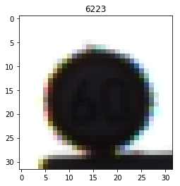

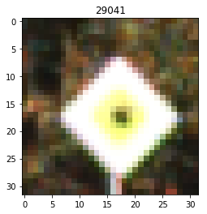

[figure not shown]

[figure not shown]

[figure not shown]

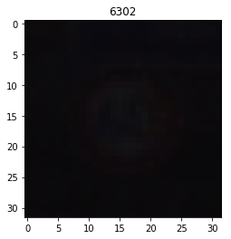

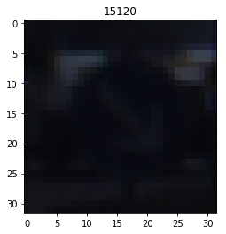

```python
bad_samples = [6223, 29041, 19591, 28593, 7657, 6302, 15120]

for ind, img in enumerate(X_train[bad_samples]):
    plt.figure()
    plt.title(bad_samples[ind])
    plt.imshow(img)
```

### High Variance on Brightness

Some kinds of pre-processing about contrast and brightness might be needed.

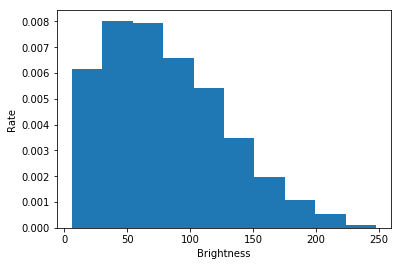

```python
R, G, B = X_train[:,:,:,0], X_train[:,:,:,1], X_train[:,:,:,2]
brightness = np.round(np.mean(0.2126*R + 0.7152*G + 0.0722*B, axis=(1,2)))

plt.xlabel("Brightness")
plt.ylabel("Rate")
_ = plt.hist(brightness, density=True)
```

### Dark Samples

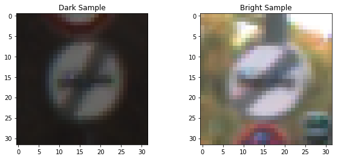

```python
f, (ax1, ax2) = plt.subplots(1,2, figsize=(10,4))
ax1.set_title('Dark Sample')
ax1.imshow(X_train[5])

ax2.set_title('Bright Sample')
ax2.imshow(X_train[100])
```

## Step 2: Design and Test a Model Architecture

### Pre-process the Data Set

Although **grayscale** was so simple, it actually made the result better and training faster. But since I noticed some images were too dark and some were bright, I thought I should balance it and believed it would help my model work better.

I chose `CLAHE` for pre-processing because it could normalize the brightness according to the areas' brightness, which meant it could probably make dark areas brighter or bright areas darker.

```python
def CLAHE(img, tileGridSize=(3,3)):
    img = img.reshape((32,32,3))
    img = cv2.cvtColor(img, cv2.COLOR_RGB2GRAY)
    clahe = cv2.createCLAHE(clipLimit=2.0, tileGridSize=tileGridSize)
    return clahe.apply(img).reshape(-1, 32*32)
```

```python
X_train_normed = X_train.reshape(-1, 32*32*3)
X_train_normed = np.apply_along_axis(CLAHE, 1, X_train_normed, (3,3)).astype(np.float32).reshape(-1, 32, 32, 1)

X_valid_normed = X_valid.reshape(-1, 32*32*3)
X_valid_normed = np.apply_along_axis(CLAHE, 1, X_valid_normed, (3,3)).astype(np.float32).reshape(-1, 32, 32, 1)

X_test_normed = X_test.reshape(-1, 32*32*3)
X_test_normed = np.apply_along_axis(CLAHE, 1, X_test_normed, (3,3)).astype(np.float32).reshape(-1, 32, 32, 1)
```

### `CLAHE` Examples

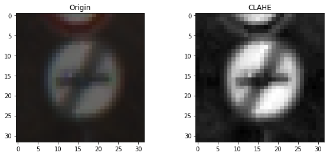

```python
def compare_origin_normed(index):
    f, (ax1, ax2) = plt.subplots(1,2, figsize=(10,4))
    ax1.set_title('Origin')
    ax1.imshow(X_train[index])

    ax2.set_title('CLAHE')
    ax2.imshow(X_train_normed[index].reshape((32,32)), cmap='gray')

compare_origin_normed(5)
```

### Model Architecture

```python
def LeNet(x):
    mu = 0
    sigma = 0.1

    conv1_W = tf.Variable(tf.truncated_normal(shape=(5,5,1,16), mean = mu, stddev = sigma))
    conv1_b = tf.Variable(tf.zeros(16))
    conv1 = tf.nn.conv2d(x, conv1_W, strides=[1,1,1,1], padding = 'SAME') + conv1_b
    conv1 = tf.nn.relu(conv1)
    conv1 = tf.nn.max_pool(conv1, ksize=[1,2,2,1], strides=[1,2,2,1], padding='VALID')

    conv2_W = tf.Variable(tf.truncated_normal(shape=(5,5,16,32), mean = mu, stddev = sigma))
    conv2_b = tf.Variable(tf.zeros(32))
    conv2 = tf.nn.conv2d(conv1, conv2_W, strides=[1,1,1,1], padding = 'SAME') + conv2_b
    conv2 = tf.nn.relu(conv2)
    conv2 = tf.nn.max_pool(conv2, ksize=[1,2,2,1], strides=[1,2,2,1], padding='VALID')

    conv3_W = tf.Variable(tf.truncated_normal(shape=(5,5,32,64), mean = mu, stddev = sigma))
    conv3_b = tf.Variable(tf.zeros(64))
    conv3 = tf.nn.conv2d(conv2, conv3_W, strides=[1,1,1,1], padding = 'SAME') + conv3_b
    conv3 = tf.nn.relu(conv3)
    conv3 = tf.nn.max_pool(conv3, ksize=[1,2,2,1], strides=[1,2,2,1], padding='VALID')

    fc0 = flatten(conv3)

    fc1_W = tf.Variable(tf.truncated_normal(shape=(np.int(fc0.shape[1]),312), mean=mu, stddev=sigma))
    fc1_b = tf.Variable(tf.zeros(312))
    fc1 = tf.matmul(fc0, fc1_W) + fc1_b
    fc1 = tf.nn.relu(fc1)
    do1 = tf.nn.dropout(fc1, 0.8)

    fc2_W = tf.Variable(tf.truncated_normal(shape=(312,256), mean=mu, stddev=sigma))
    fc2_b = tf.Variable(tf.zeros(256))
    fc2 = tf.matmul(do1, fc2_W) + fc2_b
    fc2 = tf.nn.relu(fc2)
    do2 = tf.nn.dropout(fc2, 0.6)

    fc3_W = tf.Variable(tf.truncated_normal(shape=(256,128), mean=mu, stddev=sigma))
    fc3_b = tf.Variable(tf.zeros(128))
    fc3 = tf.matmul(do2, fc3_W) + fc3_b
    fc3 = tf.nn.relu(fc3)

#     fc4_W = tf.Variable(tf.truncated_normal(shape=(256,128), mean=mu, stddev=sigma))
#     fc4_b = tf.Variable(tf.zeros(128))
#     fc4 = tf.matmul(fc3, fc4_W) + fc4_b
#     fc4 = tf.nn.relu(fc4)
    do3 = tf.nn.dropout(fc3, 0.5)

    fc5_W = tf.Variable(tf.truncated_normal(shape=(128,n_classes), mean=mu, stddev=sigma))
    fc5_b = tf.Variable(tf.zeros(n_classes))
    logits = tf.matmul(do3, fc5_W) + fc5_b

    return logits
```

```python
x = tf.placeholder(tf.float32, (None, 32, 32, 1))
y = tf.placeholder(tf.int32, (None))
one_hot_y = tf.one_hot(y, n_classes)
```

### Train, Validate and Test the Model

I used **cross entropy** as my model's loss function and initial the **learning rate** to **5e-4** (normal setting for `AdamOptimizer`).

And `BATCH_SIZE` was 64, which was also a common choice. I haved tried to set BATCH_SIZE bigger to make the training faster but the learning rate was hard to configure.

```python
lr = 5e-4
BATCH_SIZE = 64

logits = LeNet(x)
loss = tf.reduce_mean(tf.nn.softmax_cross_entropy_with_logits(logits=logits, labels=one_hot_y))

optimizer = tf.train.AdamOptimizer(learning_rate=lr)
training_op = optimizer.minimize(loss)
```

[output not shown]

```python
correct_prediction = tf.equal(tf.argmax(logits,1), tf.argmax(one_hot_y, 1))
accuracy_op = tf.reduce_mean(tf.cast(correct_prediction, tf.float32))

def evaluate(X_data, y_data):
    num_examples = len(X_data)
    total_acc = 0
    sess = tf.get_default_session()
    for offset in range(0, num_examples, BATCH_SIZE):
        batch_x, batch_y = X_data[offset:offset+BATCH_SIZE], y_data[offset:offset+BATCH_SIZE]
        acc = sess.run(accuracy_op, feed_dict={x:batch_x, y:batch_y})
        total_acc += (acc * len(batch_x))

    return total_acc / num_examples
```

```python
EPOCHS = 0

with tf.Session() as sess:
    # Train from zero
    sess.run(tf.global_variables_initializer())

    # Train from saved models
#     saver = tf.train.Saver()
#     saver.restore(sess, './saved_models/Official_Model_4_0.939683')

    num_examples = len(X_train_normed)
    print("Training...")
    print()
    for i in range(EPOCHS):
        X_train_normed, y_train = shuffle(X_train_normed, y_train)
        for offset in range(0, num_examples, BATCH_SIZE):
            end = offset + BATCH_SIZE
            batch_x, batch_y = X_train_normed[offset:end], y_train[offset:end]
            sess.run(training_op, feed_dict={x:batch_x, y:batch_y})

        validation_acc = evaluate(X_valid_normed, y_valid)
        print("EPOCH {} ...".format(i))
        print("Validation Accuracy = {:.5f}".format(validation_acc))
        print()

        if validation_acc >= 0.93:
            try:
                saver
            except NameError:
                saver = tf.train.Saver()
            saver.save(sess, "./saved_models/Official_Model_{}_{:.6f}".format(i, validation_acc))
            print("Model {} saved".format(i))
    print("Congratulations! Training was finished!")
```

```
Training...

Congratulations! Training was finished!
```

### Solution Approach

#### Correct pre-processing was really important

I applied the 0-mean and 1-std to each pixels and it made the data untrainable for some of the images are too dark and some are too bright. CLAHE was good for this task.

#### Learning rate was essential

With learning rate of 5e-4, it took over 330 epochs to get to the best. Obviously, with a lower learning rate, it might be much longer than that. But in contrast, if the learning rate was too large, then the training would be unstable and sometimes likely to step back to the initial point.

#### Baseline gave me confidence

With using a good pre-processing and a good learning rate, I got a 82% accuracy by the `LeNet` (about 200 epochs). And I was clear that I still had some useful algorithms to enhance that. First I tried to built a deeper neural network, but training was slow, so I applied another useful algorithms named `dropout` to speed it up.

#### Decide the final structure

I was not training hundreds of epochs after each modification applied to the network. I watched the accuracy of the head 50 epoch, if it slow down at about 70%, it might probably not be a nice shot. For the first time I noticed the accuracy rised slow down at 83%, I thought the framework of the network structure was correct, so I tried a few different learning rate. Finally, I was managed to get 93% accuracy at validation set.

```python
with tf.Session() as sess:
    saver = tf.train.Saver()
    saver.restore(sess, './saved_models/Official_Model_4_0.939683')
    eval_train = evaluate(X_train_normed, y_train)
    print("Train Set Accuracy is {}".format(eval_train))
    eval_valid = evaluate(X_valid_normed, y_valid)
    print("Validation Set Accuracy is {}".format(eval_valid))
    eval_test = evaluate(X_test_normed, y_test)
    print("Test Set Accuracy is {}".format(eval_test))
```

```
INFO:tensorflow:Restoring parameters from ./saved_models/Official_Model_4_0.939683
Train Set Accuracy is 0.984568522083968
Validation Set Accuracy is 0.9346938775510204
Test Set Accuracy is 0.9229612034743302
```

## Step 3: Test a Model on New Images

To give yourself more insight into how your model is working, download at least five pictures of German traffic signs from the web and use your model to predict the traffic sign type.

You may find `signnames.csv` useful as it contains mappings from the class id (integer) to the actual sign name.

### Load and Output the Images

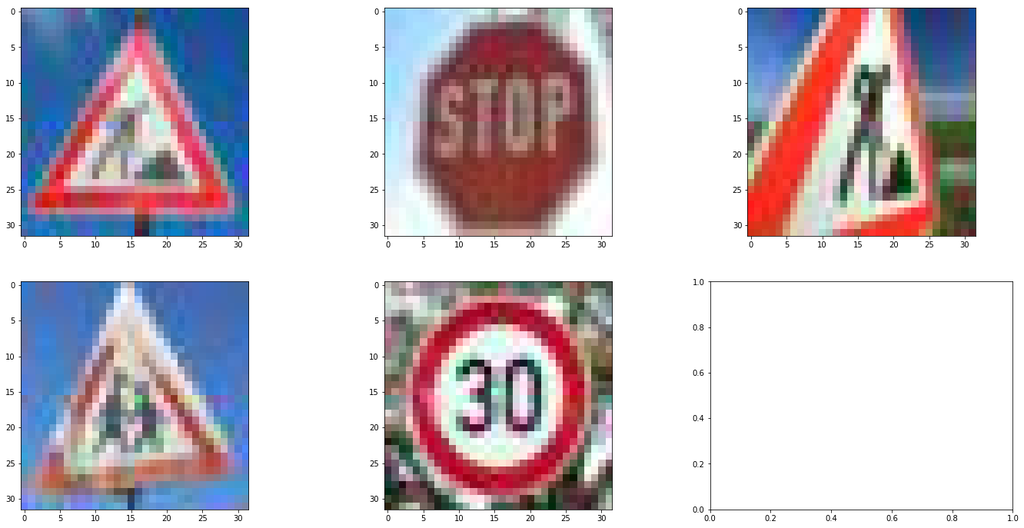

```python
import pandas as pd
import matplotlib.image as mpimg
import glob

names = pd.read_csv('./signnames.csv')
names = np.array(names.iloc[:, 1])

test_files = glob.glob('./test_images/*')

f, (ax) = plt.subplots(2, 3, figsize=(24, 12))

for ind, file in enumerate(test_files):
    img = mpimg.imread(file)
    ax[np.int(ind // 3)][np.int(ind % 3)].imshow(img)
```

### Predict the Sign Type for Each Image

```
INFO:tensorflow:Restoring parameters from ./saved_models/Official_Model_4_0.939683
```

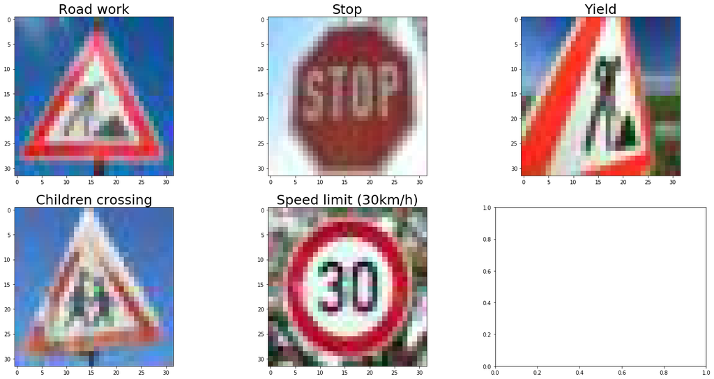

```python
test_five = []

for file in test_files:
    img = mpimg.imread(file)
    test_five.append(img)

test_five = np.array(test_five)
test_five_normed = test_five.reshape(-1, 32*32*3)
test_five_normed = np.apply_along_axis(CLAHE, 1, test_five_normed, (3,3)).astype(np.float32).reshape(-1, 32, 32, 1)

pred_classes = None
pred_logits = None

with tf.Session() as sess:
    saver = tf.train.Saver()
    saver.restore(sess, './saved_models/Official_Model_4_0.939683')

    pred_logits = sess.run(logits, feed_dict={x:test_five_normed})
    pred_classes = np.argmax(pred_logits, axis=1)
    f, (ax) = plt.subplots(2, 3, figsize=(24, 12))

    for ind, file in enumerate(test_five):
        ax_tmp = ax[np.int(ind // 3)][np.int(ind % 3)]
        ax_tmp.set_title(names[pred_classes[ind]], size=25)
        ax_tmp.imshow(test_five[ind])
```

### Output Top 5 Softmax Probabilities For Each Image Found on the Web

[figure not shown]

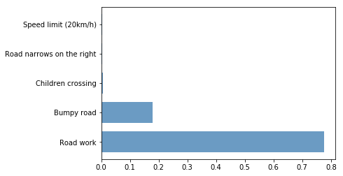

[figure not shown]

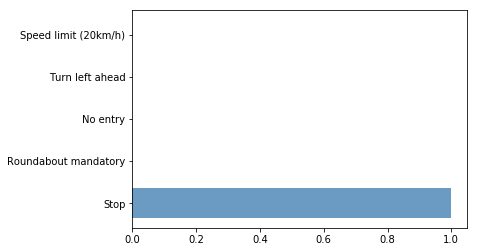

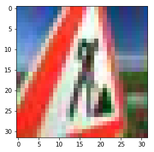

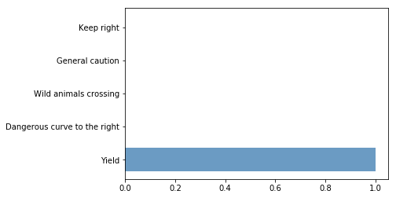

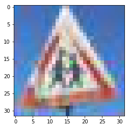

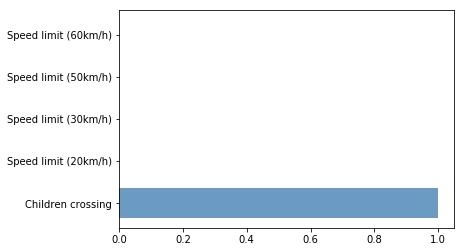

[figure not shown]

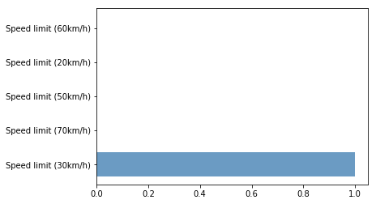

```python
with tf.Session() as sess:
    test_probs = sess.run(tf.nn.softmax(pred_logits))
    test_top5 = sess.run(tf.nn.top_k(test_probs, 5))

    for i in range(5):
        plt.figure('origin' + str(i))
        plt.imshow(test_five[i])
        plt.figure('probs' + str(i))
        plt.barh(range(5), test_top5[0][i], height=0.7, color='steelblue', alpha=0.8)      # 从下往上画
        plt.yticks(range(5), names[test_top5[1][i]])
```